# VisNA Demonstration

2024-11-29

# Introduction

VisNA is an R visualisation package that comes with 2 main functions `ggNAs` and `ggpairsNAs` to support missing data patterns summary and aids in missing data mechanisms identification.

Before we start, let’s install the package and load the necessary libraries and dataset.

```r
# Install
# if (!require("devtools")) install.packages("devtools")
# devtools::install_github("tranlevantra/VisNA")

# Load packages
library(VisNA)
library(dplyr)
library(ggplot2)

# Load dataset
data(HMEQ)
```

# Data

`HMEQ` is a open-sourced dataset that contains information on home equity loans and the credit risk associated with them. It is included in this package, available with `data(HMEQ)`, for demonstration purposes.

The dataset contains 5960 observations and 13 variables. The variables are as follows:

- *BAD*: `binary` 1 = client defaulted on loan, 0 = loan repaid
- *LOAN*: `numerical` Amount of the loan request
- *MORTDUE*: `numerical` Amount due on existing mortgage
- *VALUE*: `numerical` Value of current property
- *REASON*: `categorical` DebtCon = debt consolidation, HomeImp = home improvement
- *JOB*: `categorical` Occupational categories
- *YOJ*: `numerical` Years at present job
- *DEROG*: `numerical` Number of derogatory reports
- *DELINQ*: `numerical` Number of delinquent credit lines
- *CLAGE*: `numerical` Age of oldest credit line in months
- *NINQ*: `numerical` Number of recent credit inquiries
- *CLNO*: `numerical` Number of credit lines
- *DEBTINC*: `numerical` Debt-to-income ratio

# Main Usage

## Summary of Missing Data

The `ggNAs` function creates a stacked bar plot that shows the proportions missing and non-missing values for each variable in the dataset, with the option to group by a response variable.

Patterns of missingness can be generated with default `ggNAs` while the count labels can be added later using styling options from `ggplot2` functions.

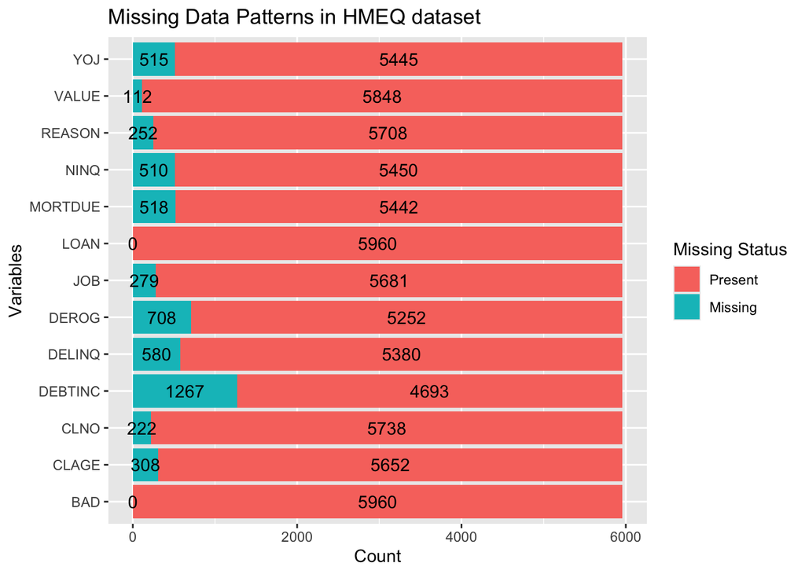

```r
ggNAs(data = HMEQ) +
  # Customize options with ggplo2 functions
  scale_fill_discrete(
    name = "Missing Status",                                 # New legend's title
    labels = c("na" = "Missing", "not_na" = "Present")       # New labels for legend items
    ) +
  geom_text(
    aes(label = count),                    # Add count labels
    position = position_stack(vjust = 0.5) # Position at the middle of the bar
    ) +
  labs(
    title = "Missing Data Patterns in HMEQ dataset", # New title of the plot
    y = "Variables",                                 # New Y-axis label
    x = "Count")                                     # New X-axis label
```

## MNAR Investigation

*Missing Not at Random (MNAR)* occurs when missingness depends on the levels of the subject of interest.

Below plot was generated using the `ggNAs` function with grouping option to investigate missing data patterns in the independent variables by levels of the dependent variable `BAD`(`BAD = 1` is when the client defaulted on the loan, `BAD = 0` is when the loan was repaid).

From the plot, for `BAD = 1` (client defaulted), the missing rate for `DEBTINC` (debt-to-income ratio) is higher compared to `BAD = 0` (loan repaid). In other words, people who defaulted on the loan are more likely not to report their debt-to-income ratio.

Because the missingness of `DEBTINC` (debt-to-income ratio) is associated with the dependent variable `BAD`, the missing data mechanism for `DEBTINC` is likely MNAR.

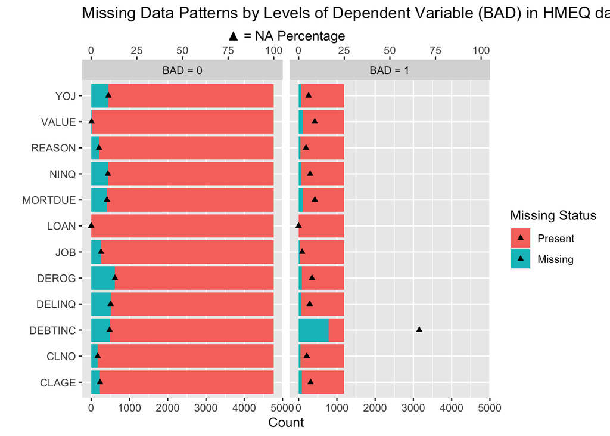

```r
ggNAs(data = HMEQ, response = "BAD") +
  # Begin customized options with ggplo2 functions
  scale_fill_discrete(
    name = "Missing Status",               # New legend title
    labels = c("Present", "Missing")       # New labels for legend items
    ) +
  labs(
    title = "Missing Data Patterns by Levels of Dependent Variable (BAD) in HMEQ dataset", # New title of the plot
    x = "Count",                                                                          # New X-axis label
    y = "")                                                                               # New Y-axis label
```

## MAR Investigation

*Missing at Random (MAR)* occurs when the likelihood of missingness is influenced by observed data but not by the missing values themselves.

The `ggpairsNAs` function visualises missing data patterns between variable pairs in the dataset:

- The upper triangle displays side-by-side bar plots, illustrating the extent of missingness within each variable pair and across the dataset.
- The lower triangle features Venn diagrams, where the overlap represents the proportion of jointly missing information.
- The diagonal shows the total number of missing values for each variable.

For example, the Venn diagram for `CLAGE` (age of the oldest credit line, in months) and `CLNO` (number of credit lines) shows a large intersection area, with comparable missing value counts for both variables. This pattern suggests a MAR mechanism, indicating that if the age of the oldest credit line is missing, the number of credit lines is also likely to be missing.

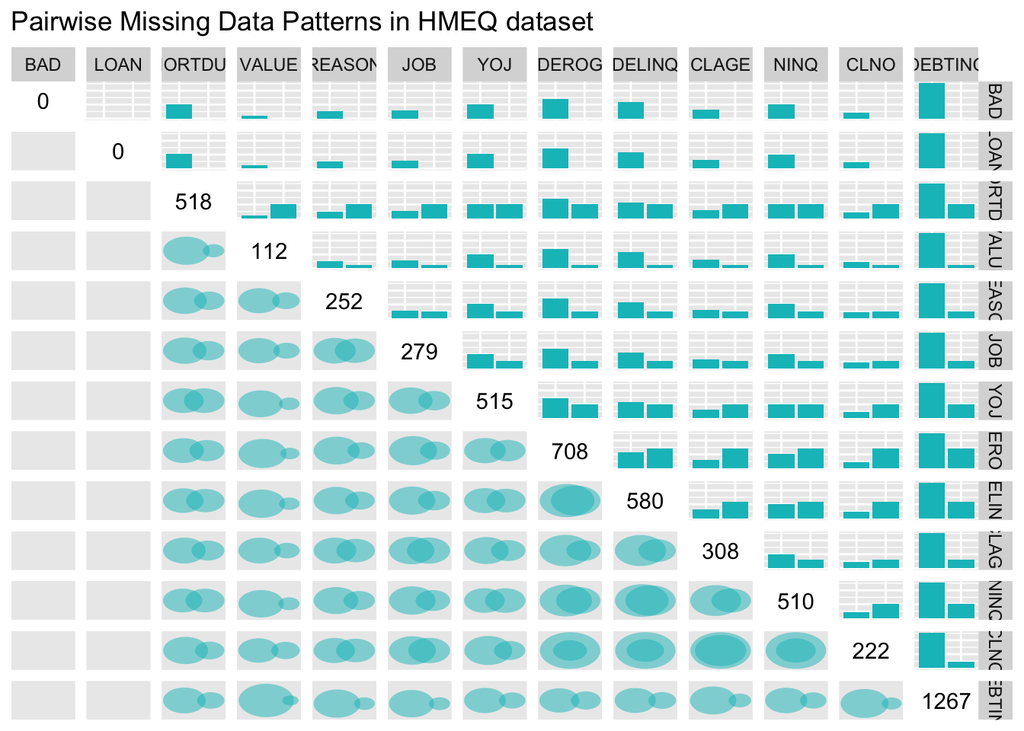

```r
ggpairsNAs(data = HMEQ) +
  labs(
    title = "Pairwise Missing Data Patterns in HMEQ dataset" # New title of the plot
    )
```

# Advanced Usage

This package effectively integrates with tidyverse workflow and supports further customisation of the plots using ggplot2 and GGally functions.

## Numerical response variable

The `ggNAs` function can be used to study the missing data patterns by a numerical response variable, however, binning the response variable into categories is required.

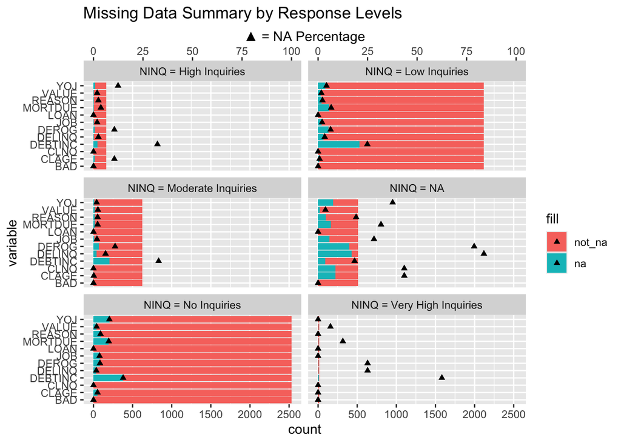

```r
# Binning the NINQ variable into categories
HMEQ <- HMEQ %>%
  mutate(NINQ = case_when(
    NINQ == 0 ~ "No Inquiries",
    NINQ %in% 1:2 ~ "Low Inquiries",
    NINQ %in% 3:5 ~ "Moderate Inquiries",
    NINQ %in% 6:10 ~ "High Inquiries",
    NINQ >= 11 ~ "Very High Inquiries",
    TRUE ~ as.character(NINQ)
  ))

# Investigating missing data patterns by NINQ
ggNAs(data = HMEQ, response = "NINQ")
```

## Interaction terms

The `ggNAs` is particularly useful when we want to investigate the missing data patterns influenced by the interaction between two or more variables.

Also, be cautious with NA percentages in small categories (<30 observations). Small sample sizes can lead to misleading results, much like tossing a coin 3 times and getting 3 heads does not prove the coin is biased.

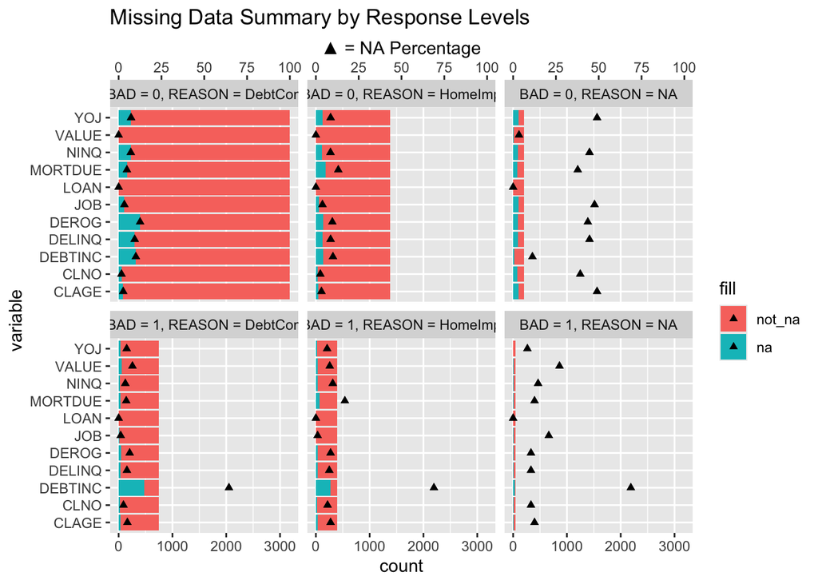

```r
ggNAs(data = HMEQ,
      response = c("BAD", "REASON"), # Interactions between BAD and REASON
      ncol = 3)                      # Arrange the plots in 3 columns
```

## Customisation with ggplot2 and GGally

The `ggNAs` and `ggpairsNAs` functions return ggplot2 and GGally objects, respectively. This allows for further customisation using ggplot2 and GGally functions.

```r
# From R console, type the following to view the documentation
?VisNA::ggNAs()
?VisNA::ggpairsNAs()
```